# Economic Hardship Dashboard

**Offline Version — San Diego County**

This version loads pre-built data from GitHub. No Census API key needed. All analysis is complete. Your task: write the three policy recommendations. Submit your completed .qmd and .html to Canvas.

[interactive chart not shown]

Counties Mapped

3,220

Highest Hardship County

Guánica Municipio (5.68)

San Diego County, CA National Rank

#2759 of 3220

| County | State | Hardship |
| --- | --- | --- |
| Guánica Municipio | Puerto Rico | 5.684 |
| Utuado Municipio | Puerto Rico | 5.176 |
| Adjuntas Municipio | Puerto Rico | 4.882 |
| Mayagüez Municipio | Puerto Rico | 4.658 |
| Lajas Municipio | Puerto Rico | 4.357 |
| Florida Municipio | Puerto Rico | 4.23 |
| Guayanilla Municipio | Puerto Rico | 4.157 |
| Jayuya Municipio | Puerto Rico | 4.151 |
| Luquillo Municipio | Puerto Rico | 4.129 |
| Maunabo Municipio | Puerto Rico | 3.92 |

[output cut: 10 more lines]

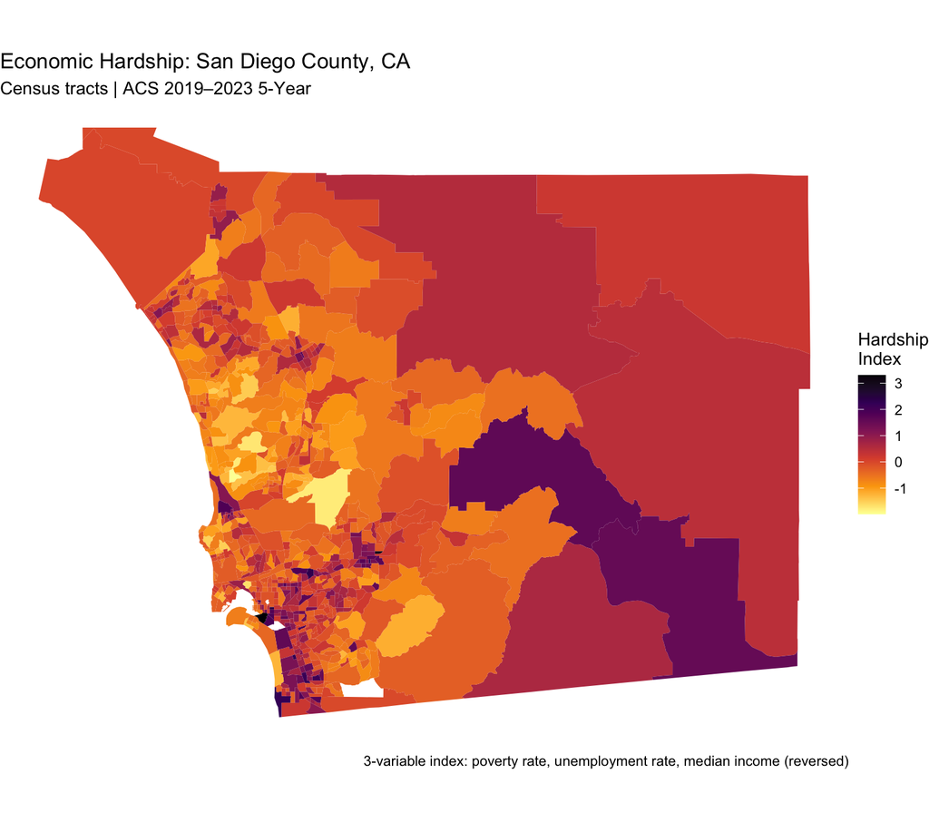

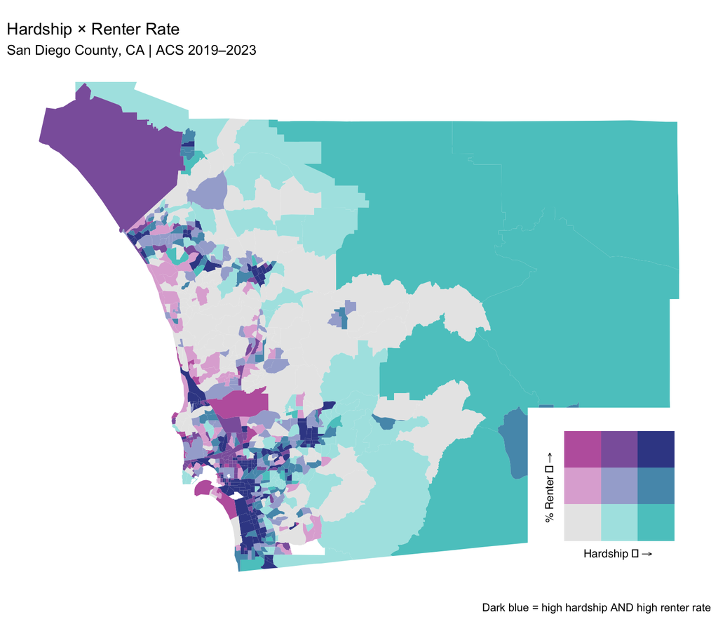

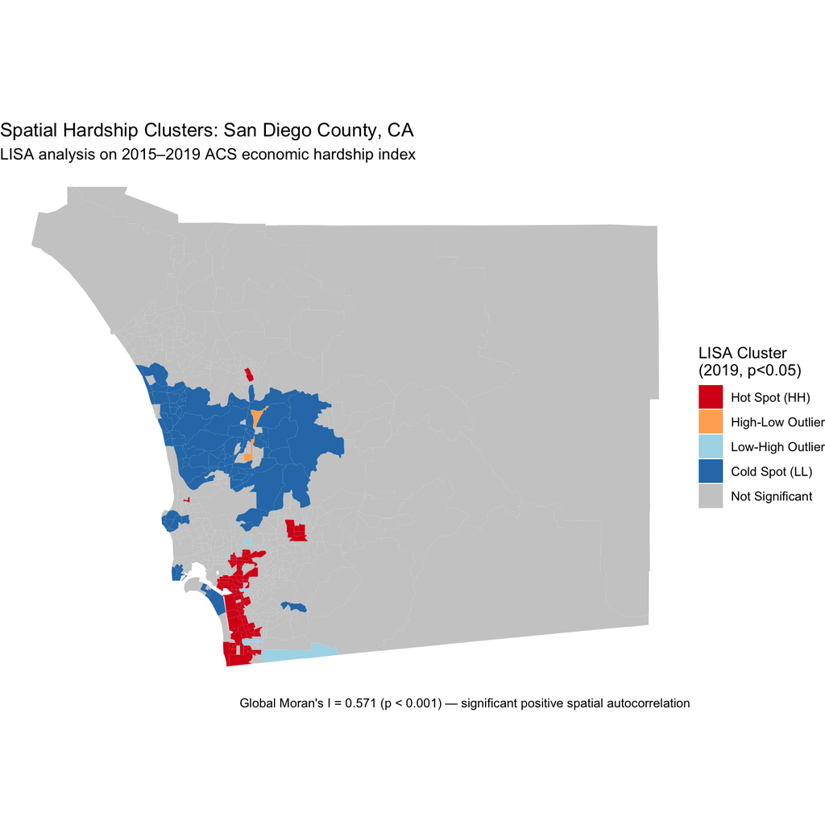

Hot Spot Tracts (HH)